# Flights delays analysis Part. 2

```r
library(tidyverse)
library(GGally)
```

```r
weather_impact <- read_csv(here::here("cleaned_data/weather_imp.csv"))
```

## Business Question 2: Are there any other factors that together with `wind speed`, `wind_dir` and `visibility` influence the length of flights delays in the three airports of interest?

### Airlines

First of all let’s have a look to see if there is a particular difference in terms of flights delays length among the different airlines.

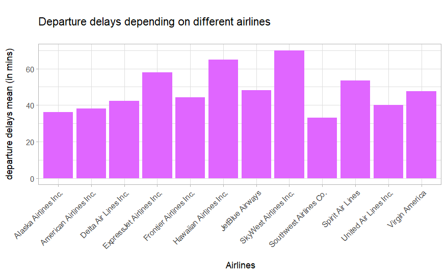

```r
weather_impact %>%
  group_by(airline) %>%
  summarise(mean_dep_delay = mean(dep_delay, na.rm = TRUE)) %>%
  ggplot()+
  aes(x = airline, y = mean_dep_delay)+
  geom_col(position = "dodge", fill = "mediumorchid1")+
  theme_light()+
  labs(
    x = "\n Airlines",
    y = "departure delays mean (in mins)\n",
    title = "\nDeparture delays depending on different airlines\n"
  )+
  scale_x_discrete(guide = guide_axis(angle = 45))
```

It seems that `Hawaiian Airlines` and `SkyWest Airlines` register the longest delays.

Let’s have a look now at how this is related to the weather.

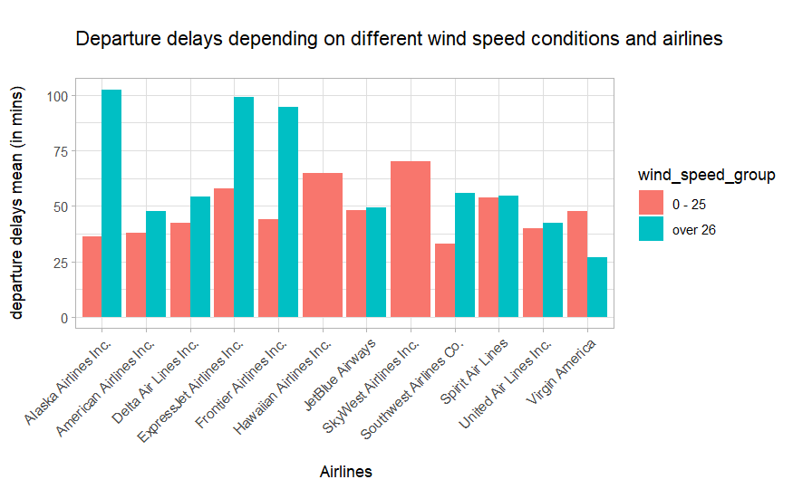

```r
weather_impact %>%
  group_by(airline, wind_speed_group) %>%
  summarise(mean_dep_delay = mean(dep_delay, na.rm = TRUE)) %>%
  ggplot()+
  aes(x = airline, y = mean_dep_delay, fill = wind_speed_group)+
  geom_col(position = "dodge")+
  theme_light()+
  labs(
    x = "\n Airlines",
    y = "departure delays mean (in mins)\n",
    title = "\nDeparture delays depending on different wind speed conditions and airlines\n"
  )+
  scale_x_discrete(guide = guide_axis(angle = 45))
```

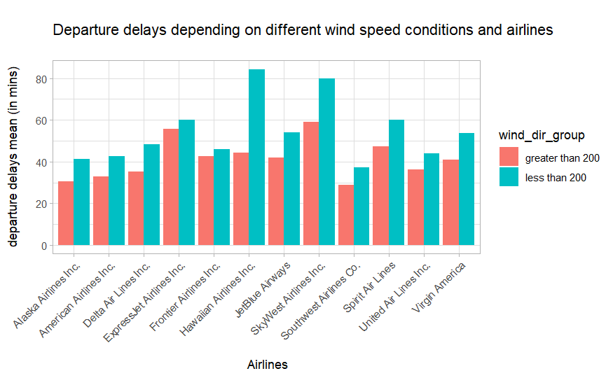

```r
weather_impact %>%
  group_by(airline, wind_dir_group) %>%
  summarise(mean_dep_delay = mean(dep_delay, na.rm = TRUE)) %>%
  ggplot()+
  aes(x = airline, y = mean_dep_delay, fill = wind_dir_group)+
  geom_col(position = "dodge")+
  theme_light()+
  labs(
    x = "\n Airlines",
    y = "departure delays mean (in mins)\n",
    title = "\nDeparture delays depending on different wind speed conditions and airlines\n"
  )+
  scale_x_discrete(guide = guide_axis(angle = 45))
```

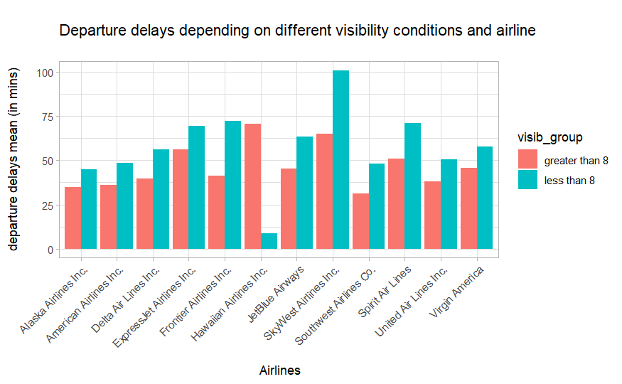

```r
weather_impact %>%
  group_by(airline, visib_group) %>%
  summarise(mean_dep_delay = mean(dep_delay, na.rm = TRUE)) %>%
  ggplot()+
  aes(x = airline, y = mean_dep_delay, fill = visib_group)+
  geom_col(position = "dodge")+
  theme_light()+
  labs(
    x = "\n Airlines",
    y = "departure delays mean (in mins)\n",
    title = "\nDeparture delays depending on different visibility conditions and airline\n"
  )+
  scale_x_discrete(guide = guide_axis(angle = 45))
```

It doesn’t seem to me that this plot add anything of particular interest to the conclusions we already drawn about visibility dependence of the length of flights delays. It seems that a few companies maybe are less affected by visibility, but generally speaking the trend seems more or less to be the same that we noticed in the general plot. For example, delays with `SkyWest Airlines` seems to be more affected by low visibility conditions than from the wind speed.

# Airports

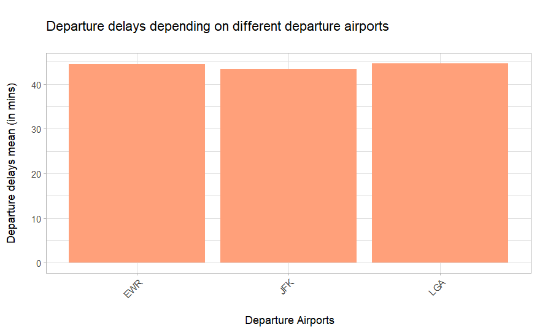

```r
weather_impact %>%
  group_by(origin) %>%
  summarise(mean_dep_delay = mean(dep_delay, na.rm = TRUE)) %>%
  ggplot()+
  aes(x = origin, y = mean_dep_delay)+
  geom_col(position = "dodge", fill = "lightsalmon")+
  theme_light()+
  labs(
    x = "\n Departure Airports",
    y = "Departure delays mean (in mins)\n",
    title = "\nDeparture delays depending on different departure airports\n"
  )+
  scale_x_discrete(guide = guide_axis(angle = 45))
```

It doesn’t seems that airports doesn’t have a particular incidence with the length of delays, but let’s have a look of the different weather conditions.

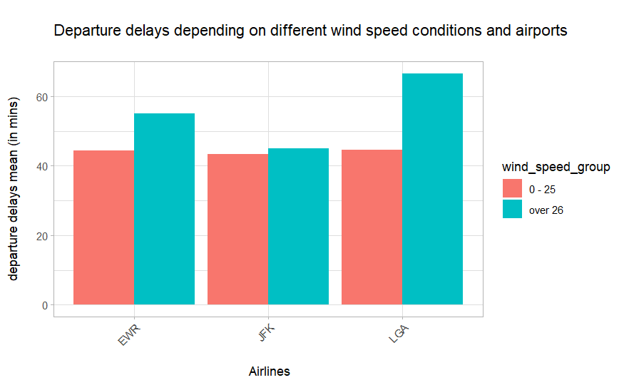

```r
weather_impact %>%
  group_by(origin, wind_speed_group) %>%
  summarise(mean_dep_delay = mean(dep_delay, na.rm = TRUE)) %>%
  ggplot()+
  aes(x = origin, y = mean_dep_delay, fill = wind_speed_group)+
  geom_col(position = "dodge")+
  theme_light()+
  labs(
    x = "\n Airlines",
    y = "departure delays mean (in mins)\n",
    title = "\nDeparture delays depending on different wind speed conditions and airports\n"
  )+
  scale_x_discrete(guide = guide_axis(angle = 45))
```

It seems that a very intense wind speed influence in some ways the length of flights delays in the airports of `La Guardia`, so as in `Newark Liberty`, which is the one we are more interested in. Less impact instead seems to have at `JFK`. However, just winds with a speed greater than 26 mph seems to have any kind of relationship, there is no significant patterns to find out for winds with a less intense speed than 26.

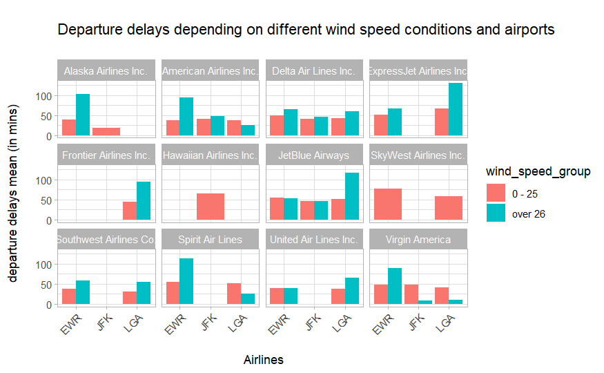

```r
weather_impact %>%
  group_by(origin, airline, wind_speed_group) %>%
  summarise(mean_dep_delay = mean(dep_delay, na.rm = TRUE)) %>%
  ggplot()+
  aes(x = origin, y = mean_dep_delay, fill = wind_speed_group)+
  geom_col(position = "dodge")+
  theme_light()+
  labs(
    x = "\n Airlines",
    y = "departure delays mean (in mins)\n",
    title = "\nDeparture delays depending on different wind speed conditions and airports\n"
  )+
  scale_x_discrete(guide = guide_axis(angle = 45))+
  facet_wrap(~airline)
```

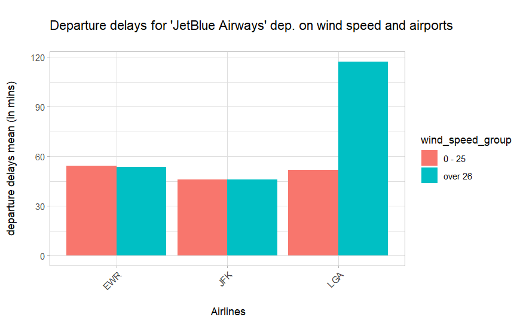

```r
weather_impact %>%
  filter(airline == "JetBlue Airways") %>%
  group_by(origin, wind_speed_group) %>%
  summarise(mean_dep_delay = mean(dep_delay, na.rm = TRUE)) %>%
  ggplot()+
  aes(x = origin, y = mean_dep_delay, fill = wind_speed_group)+
  geom_col(position = "dodge")+
  theme_light()+
  labs(
    x = "\n Airlines",
    y = "departure delays mean (in mins)\n",
    title = "\nDeparture delays for 'JetBlue Airways' dep. on wind speed and airports\n"
  )+
  scale_x_discrete(guide = guide_axis(angle = 45))
ggsave("jet_Blue.png")
```

Very few companies seems to have a certain relationship between very intense wind speed and length of delays and only in specific airports.

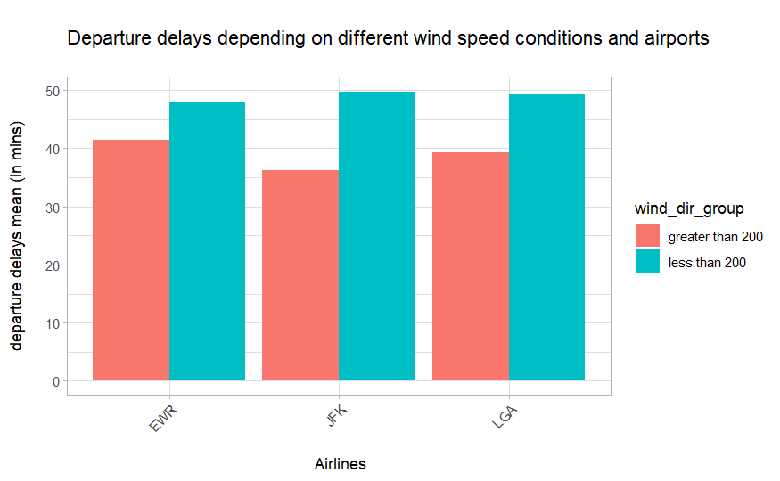

```r
weather_impact %>%
  group_by(origin, wind_dir_group) %>%
  summarise(mean_dep_delay = mean(dep_delay, na.rm = TRUE)) %>%
  ggplot()+
  aes(x = origin, y = mean_dep_delay, fill = wind_dir_group)+
  geom_col(position = "dodge")+
  theme_light()+
  labs(
    x = "\n Airlines",
    y = "departure delays mean (in mins)\n",
    title = "\nDeparture delays depending on different wind speed conditions and airports\n"
  )+
  scale_x_discrete(guide = guide_axis(angle = 45))
```

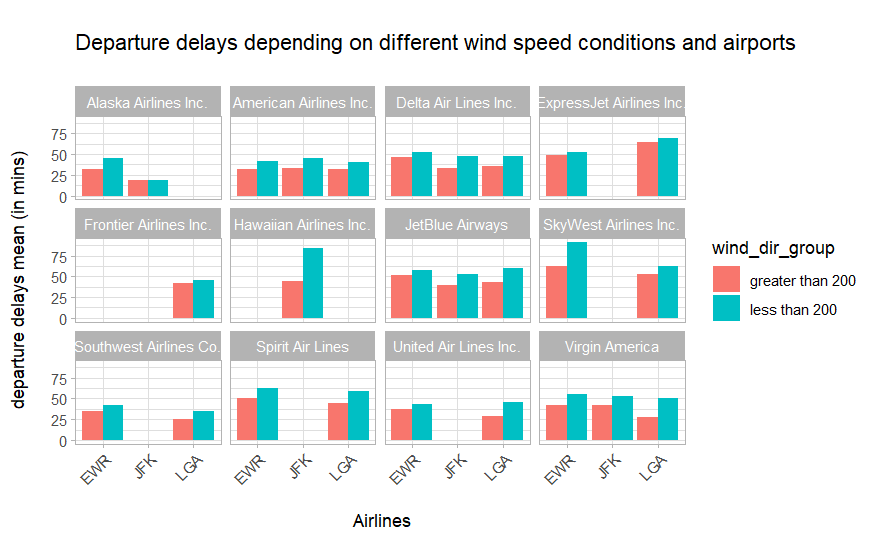

```r
weather_impact %>%
  group_by(origin, airline, wind_dir_group) %>%
  summarise(mean_dep_delay = mean(dep_delay, na.rm = TRUE)) %>%
  ggplot()+
  aes(x = origin, y = mean_dep_delay, fill = wind_dir_group)+
  geom_col(position = "dodge")+
  theme_light()+
  labs(
    x = "\n Airlines",
    y = "departure delays mean (in mins)\n",
    title = "\nDeparture delays depending on different wind speed conditions and airports\n"
  )+
  scale_x_discrete(guide = guide_axis(angle = 45))+
  facet_wrap(~airline)
```

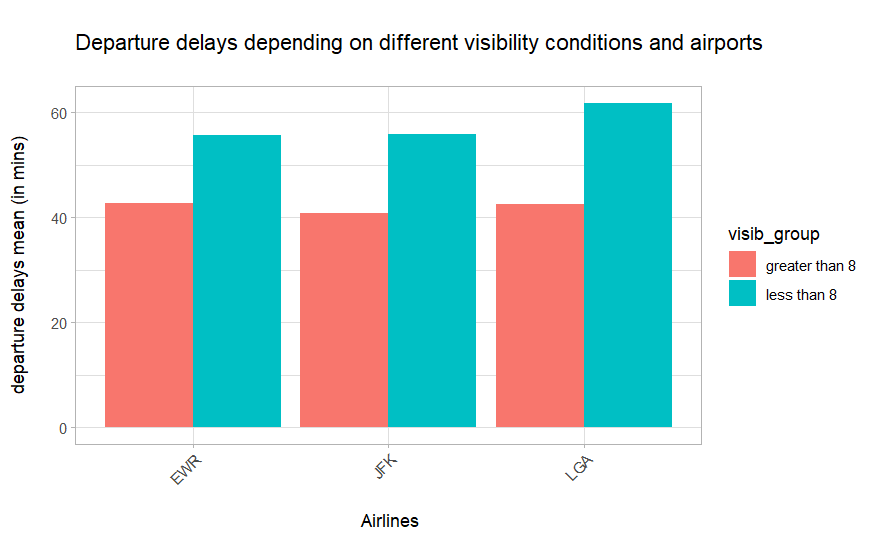

```r
weather_impact %>%
  group_by(origin, visib_group) %>%
  summarise(mean_dep_delay = mean(dep_delay, na.rm = TRUE)) %>%
  ggplot()+
  aes(x = origin, y = mean_dep_delay, fill = visib_group)+
  geom_col(position = "dodge")+
  theme_light()+
  labs(
    x = "\n Airlines",
    y = "departure delays mean (in mins)\n",
    title = "\nDeparture delays depending on different visibility conditions and airports\n"
  )+
  scale_x_discrete(guide = guide_axis(angle = 45))
```

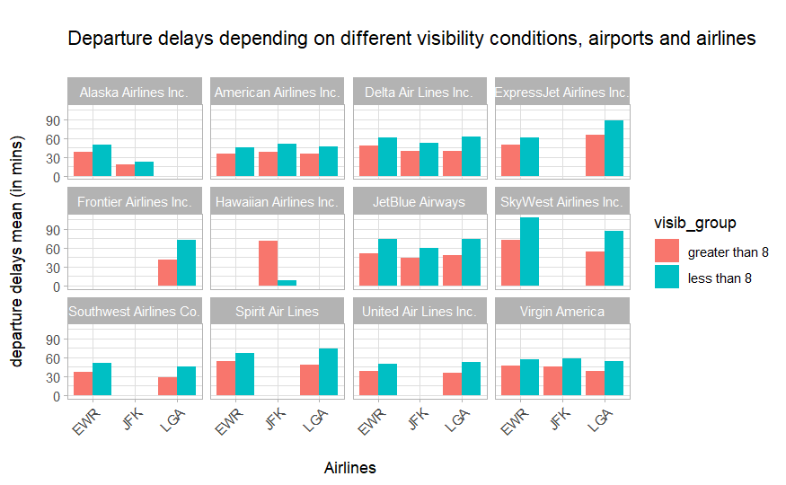

```r
weather_impact %>%
  group_by(origin, airline, visib_group) %>%
  summarise(mean_dep_delay = mean(dep_delay, na.rm = TRUE)) %>%
  ggplot()+
  aes(x = origin, y = mean_dep_delay, fill = visib_group)+
  geom_col(position = "dodge")+
  theme_light()+
  labs(
    x = "\n Airlines",
    y = "departure delays mean (in mins)\n",
    title = "\nDeparture delays depending on different visibility conditions, airports and airlines\n"
  )+
  scale_x_discrete(guide = guide_axis(angle = 45))+
  facet_wrap(~airline)
```

| mean_del |
| --- |
| 44.22642 |

| mean(dep_delay, na.rm = TRUE) |
| --- |
| 44.22642 |

[output not shown]

[output cut: 990 more lines]